# title: Use `purl()` to extract R code

Kalyango Jovan (7014430)

02-06-2021

The sale price (in thousands of dollars) and the floor size (in squared meters) for a random sample of 27 single-family houses sold in a given town during 2005 are stored in the file house2.txt.In particular, for each house, the file contains:Taxes the amount of property taxes (thousands of dollars), paid by the previous owner during 2004,Beds number of bedrooms,Baths number of bathrooms,Size floor size (squared meters),Price sale price (thousands of dollars).It has a rows-by-columns structure, where each row corresponds to a unit, each column to a statistical variable. Differently from a matrix,it can contain strings, numerical and logical values (thus allowing for the presence of both categorical and numerical variables). For example, it is possible to visualize the first 6 rows of seeds using the following instruction: house2[1:6,]. It is also organized as a list: each element of the list corresponds to a variable: The aim of the report is to fit a multiple linear regression model, in order to assess the impact of the four predictors on the sale price.I also aim to know which of the predictors has a larger impact on the Price of the house. Hence, finding the most important or useful predictor(s). The research questions are to be answered using Bayesian statistical analysis techniques such as Gibb’s sampler and metropolis-Hastings algorithm as a data set of my choice fits the analysis type.

# 1. Think about and specify prior distribution for your parameters

# 2. Program your own Gibbs sampler ?.

The goal of Bayesian inference is to maintain a full posterior probability distribution over a set of random variables. However, maintaining and using this distribution often involves computing integrals which, for most non-trivial models, is intractable. Sampling algorithms based on Monte Carlo Markov Chain(MCMC) techniques are one possible way to go about inference in such models. The idea in Gibbs sampling is to generate posterior samples by sweeping through each variable (or block of variables) to sample from its conditional distribution with the remaining variables fixed to their current values. For instance, in this case I have four predictors so,applying the multivariate approach for a Gibbs sampler of multiple linear regression with non-informative priors is done. My linear model is: $yh = xh{\beta} + e$, where ${e} = \mathcal{MVN}( {\mu}, \sigma^2 I_n)$. Here, $\mu$ is a zero-vector with length k (the number of predictors, including a 1-vector for the intercept), and $I_n$ is a n-dimensional Identity matrix (where n is the number of observations). The covariance matrix of the distribution of errors is thus a diagonal matrix where the elements on the diagonal $\sigma^2$ are all identical (representing the heteroscedastictiy assumption) and the off-diagonal elements are all zero (representing the independence of error assumption).The density of the data, given the model, is:
$$P(xh, yh| \beta, \sigma^2) = \mathcal{MVN}(\mu = \beta, \Sigma = \sigma^2I_n)$$

# 3. Include a Metropolis-Hastings step for at least one parameter

The product of prior and likelihood is the actual quantity the MCMC will be working on. This function is called the posterior (or to be exact, it’s called the posterior after it’s normalized, which the MCMC).Again, here we work with the sum because we work with logarithms posterior we use sum instead of product, the actual Metropolis-Hastings algorithm. One of the most frequent applications of this algorithm is sampling from the posterior density in Bayesian statistics. In principle,however, the algorithm may be used to sample from any integrable function. So, the aim of this algorithm is to jump around in parameter space, but in a way that the probability to be at a point is proportional to the function we sample from (this is usually called the target function). In our case this is the posterior defined in the $'code.R'$.This is achieved by starting at a random parameter value Choosing a new parameter value close to the old value based on some probability density that is called the proposal function Jumping to this new point with a probability $p(new)/p(old)$, where p is the target function, and $p>1$ means jumping as well,when we run this algorithm, distribution of the parameters it visits converges to the target distribution p. So, let’s get this in R: The first steps of the algorithm may be biased by the initial value, and are therefore usually discarded for the further analysis (burn-in time). An interesting output to look at is the acceptance rate: how often was a proposal rejected by the metropolis-hastings acceptance criterion? The acceptance rate can be influenced by the proposal function: generally, the closer the proposals are, the larger the acceptance rate. Very high acceptance rates, however, are usually not beneficial: this means that the algorithms is “staying” at the same point, which results in a suboptimal probing of the parameter space (mixing). It can be shown that the acceptance rates between 20% and 30% are optimal for typical applications, so in this case our acceptance rate is $0.91$ implies not optimal rate.

# summary

# 4. Assess convergence of the model

Traceplots show that they follow the desired form that resembles ’ caterpillar’ for all the parameters display the caterpillar like shape. This indicates that the parameters converged at the same joint posterior distribution of the model parameters.If this was not case we could, we can increase the number of iterations or introduce centering of the paramters around their means to in order the parameters to converge, but in this case there is no need to do that.

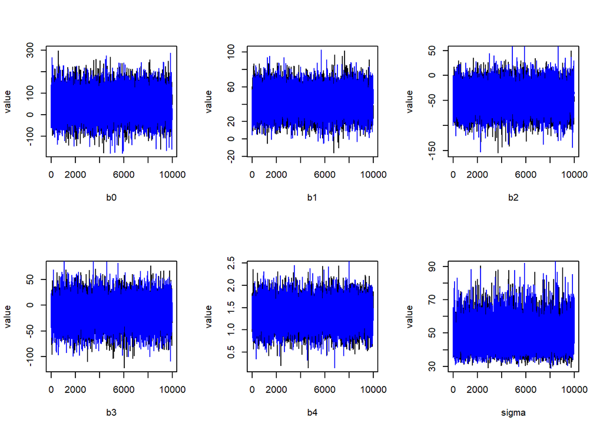

Traceplots of Model Parameters

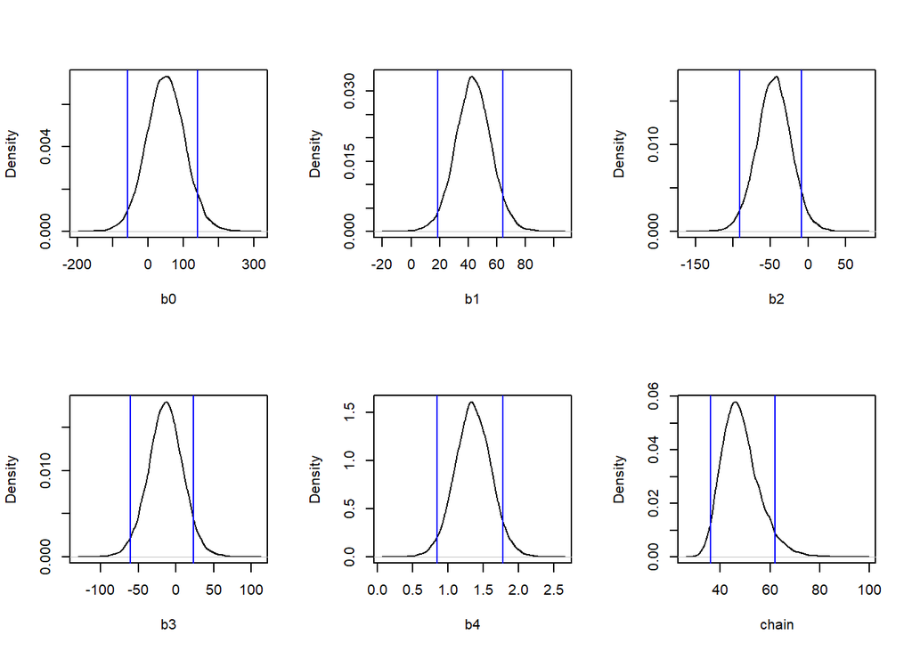

Density Plots of Model Paramters

I computed the autocorrelations of the model parameters per chain. The plots of the autocorrelation from lag0 to lag1000 of chain 1 are displayed in Figure 3. The autocorrelations of the second chain are approximately the same and can be inspected using the `acfm()` function in `code R`.

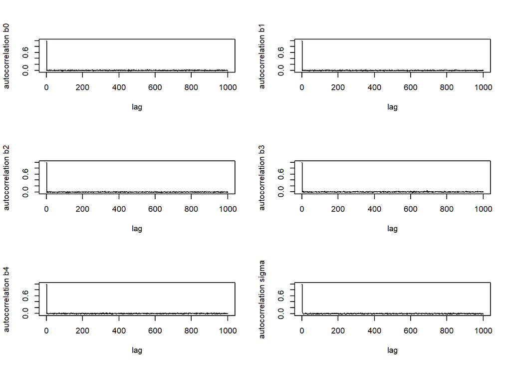

Autocorrelation Plots of Chain 1

The autocorrelations converge to zero immediately at the first lag for all parameters. This indicates rapid mixing. Hence, the sampler not only appears to have reached the joint posterior distribution, but it also appears to move through it in an efficiently. Because of this, subsequent values show independence from one another.

# 5. Check a model assumption of linear regression by means of a posterior predictive p-value

An important assumption of multiple linear regression is that the residuals of my model are normally distributed. In order to test the test the hypothesis, a posterior predictive check is conducted using r. ## Step 1: Specifying the Null-Hypothesis The Null-Hypothesis that the residuals of my model are normally distributed, is formally specified as:$Y = X{\beta} + e$, where ${e} = \mathcal{MVN}( {\mu}, \sigma^2 I_n)$

## Step 2: Sampling from the posterior distribution of the model parameters

Now, sample$\theta$, i.e. $\beta$ and $\sigma^2$ 10,000 times, using my `gibbs_spl()` function.

## Step 3: Generating the Posterior Predictive Distribution

Each of sampled values of $\theta$ from $\theta_1$ to $\theta_{10,000}$ were used to simulate data, by using the linear predictor. Hereby, $X$ was fixed. Hence, I simulated 10,000 datasets, where $\hat{Y}_t = \beta_tX$. We thus end up with:

$$[\hat{Y}_1, X], [\hat{Y}_2, X], ..., [\hat{Y}_{10000}, X]$$

Finally, I computed the *posterior-predictive (Bayesian) p-value*, as:

$p = 0.5553$.

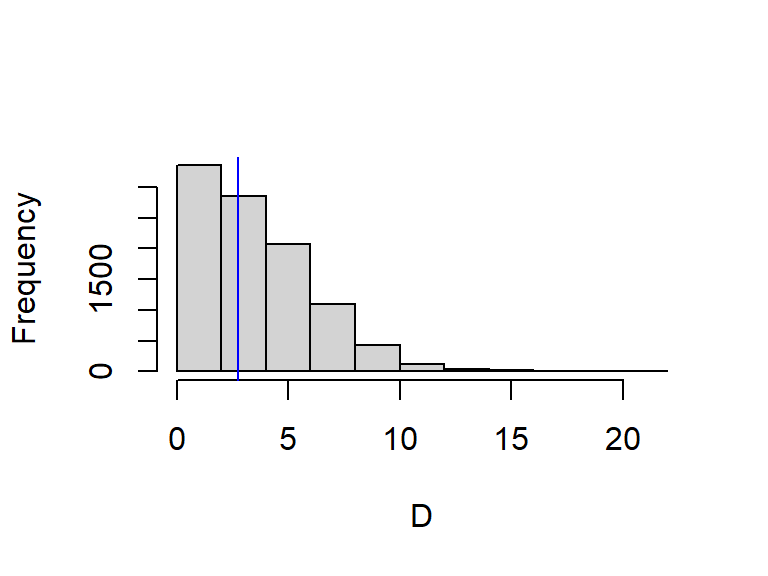

Histogram of distribution of discrepancy measures

# 6. Obtain parameter estimates, credible intervals and interpretation

The parameter estimates, which were derived by computing the mean and standard deviations of the posteriors of the two chains combined ($N = 20,000$) are displayed in Table 1.

Parameter Estimates

|  | b0 | b1 | b2 | b3 | b4 | sigma |
| --- | --- | --- | --- | --- | --- | --- |
| EAP | 49.6370000 | 43.6080000 | -45.6170000 | -13.8490000 | 1.3550000 | 48.2880000 |
| SD | 54.9030000 | 12.5880000 | 22.9740000 | 23.1800000 | 0.2570000 | 7.6000000 |
| Gelman Rubin | 0.9999500 | 0.9999600 | 0.9999500 | 0.9999500 | 0.9999500 | 0.9999500 |
| MC error | 0.3882252 | 0.0890125 | 0.1624537 | 0.1639095 | 0.0018207 | 0.0537428 |

Posterior Quantiles

|  | 2.5% | 25% | 50% | 75% | 97.5% |
| --- | --- | --- | --- | --- | --- |
| b0 | -58.043 | 13.516 | 49.514 | 85.659 | 157.590 |
| b1 | 18.851 | 35.337 | 43.549 | 51.790 | 68.672 |
| b2 | -91.321 | -60.567 | -45.456 | -30.516 | -0.657 |
| b3 | -60.053 | -28.856 | -13.710 | 1.173 | 31.773 |
| b4 | 0.847 | 1.184 | 1.353 | 1.526 | 1.868 |
| sigma | 36.073 | 42.949 | 47.391 | 52.507 | 65.860 |

# 7 Compare multiple models by means of DIC and Bayes Factor.

## DIC

The dic function, i have built suggests that a model without baths has the lowest value($DIC =289.384 $), this implies that a combination of three parameters produce the best model.

#Bayes Factor

##Frequentist Vs Bayesian There are two schools of statistical inference: Bayesian and frequentist. Both approaches allow one to evaluate evidence about competing hypotheses. I will finalize this report by reviewing and comparing the two approaches, starting from Bayes’formula.$P(A|B)=P(B|A)*P(A)/P(B)$ where $P(A|B$ is posterior,$P(B|A)$ is likelihood, $P(A)$ is prior and $P(B)$ is the total probability of the data taking into account all possible hypotheses.

The Bayesian school models uncertainty by a probability distribution over hypotheses. One’s ability to make inferences depends on one’s degree of confidence or belief in the chosen prior,and the robustness of the findings to alternate prior distributions may be relevant and important. The frequentist school only uses conditional distributions of data given specific hypotheses. The presumption is that some hypothesis is true and that the observed data is sampled from that distribution. In particular, the frequentist approach does not depend on a subjective prior that may vary from one investigator to another. Other differences are: Bayesian inference . It uses probabilities for both hypotheses and data. . Dependent of the prior and likelihood of observed data. . One required to know or construct a ‘subjective prior’. . May be computationally intensive due to integration over many parameters. Frequentist inference . Never uses or gives the probability of a hypothesis (no prior or posterior). . Depends on the likelihood $P(B|A)$ for both observed and unobserved data. . Does not require a prior. . Tends to be less computationally intensive.

Critiques and defenses *Bayesian inference* is that a subjective prior is, well, subjective.Furthermore, there are philosophical objections to assigning probabilities to hypotheses, as hypotheses do not constitute outcomes of repeatable experiments in which one can measure long-term frequency. Rather, a hypothesis is either true or false, regardless of whether one knows which is the case. In defense,it is easy to communicate a result framed in terms of probabilities of hypotheses,By trying different priors we can see how sensitive our results are to the choice of prior, Using Bayes’ theorem is logically rigorous. Once we have a prior all our calculations have the certainty of deductive logic and data can be used as it comes in. *Frequentist inference* there is ad-hoc and does not carry the force of deductive logic and experiments must be fully specified ahead of time. In defense, It is objective: allowing a larger audience to understand statistics. Frequentist experimental design demands a careful description of the experiment and methods of analysis before starting. This helps control for experimenter bias.